### Weather events in the United States with largest tolls on human health and economy

#### Data processing

Storm Data for the United States is provided by the National Oceanic and Atmospheric Administration (NOAA). The storm data .csv file containing records from 1950 to 2011 was loaded into R as stormdata for data processing.

```r
stormdata <-read.csv("stormdata.csv.bz2",stringsAsFactors = FALSE, header=TRUE)
```

##### *Impacts to human health*

Certain types of events are more harmful than others in respect to human health. Events that occur more frequently are more likely to cause greater harm than rarer events, and events that last for a longer duration or are more severe are more likely to cause more fatalities than injuries. The storm data provides information on the number of injuries and fatalities per weather event. Stormdata lists 985 total different events. Stormdata was subset and previewed to look at only those events with at least 1 injury or fatality.

```r
#Total weather events in stormdata
length(unique(stormdata$EVTYPE))
```

```
## [1] 985
```

```r
#subsetting to look at events causing injuries or fatalities
hurt <- subset(stormdata, FATALITIES >0 | INJURIES > 0)
#Total weather events with adverse effects on human health
length(unique(hurt$EVTYPE))
```

```
## [1] 220
```

```r
#Data preview
head(sort(unique(hurt$EVTYPE)),20)
```

```
##  [1] "AVALANCE"                 "AVALANCHE"
##  [3] "BLACK ICE"                "BLIZZARD"
##  [5] "blowing snow"             "BLOWING SNOW"
##  [7] "BRUSH FIRE"               "COASTAL FLOOD"
##  [9] "Coastal Flooding"         "COASTAL FLOODING"
## [11] "COASTAL FLOODING/EROSION" "Coastal Storm"
## [13] "COASTAL STORM"            "COASTALSTORM"
## [15] "Cold"                     "COLD"
## [17] "COLD AND SNOW"            "Cold Temperature"
## [19] "COLD WAVE"                "COLD WEATHER"
```

Many event types strings were redundant, such as from mispellings (e.g., avalance), different formattings (e.g. case differences), or nuanced category names (e.g., cold vs. cold weather). To address these problems, event type strings were first reformatted to all uppercase text. Second, event types were reclassified into 31 broad storm event categories.

```r
#All text to uppercase
hurt$EVTYPE <- toupper(hurt$EVTYPE)
#Creating simplified event type classification
hurt$EVENT <- hurt$EVTYPE

hurt$EVENT <- gsub("WINTRY MIX|WINTER WEATHER/MIX|WINTER WEATHER MIX|WINTER STORM HIGH WINDS|WINTER WEATHER|WINTER STORMS|WINTER STORM|WINTER STORM/WEATHERS|WINTER STORM/WEATHER HIGH SURF SURF WIND",
                   "WINTER STORM/WEATHER",hurt$EVENT)
hurt$EVENT <- gsub("AVALANCE","AVALANCHE",hurt$EVENT)
hurt$EVENT <- gsub("STORM SURGE|STORM SURGE/TIDE|COASTAL FLOODING|TIDAL FLOODING|COASTAL FLOODING/EROSION|TSUNAMI",
                   "COASTAL FLOOD",hurt$EVENT)
hurt$EVENT <- gsub("COASTALSTORM","COASTAL STORM",hurt$EVENT)
hurt$EVENT <- gsub("RECORD COLD|COLD/WIND CHILL|COLD/WINDS|LOW TEMPERATURE|COLD TEMPERATURE|COLD WEATHER|COLD WAVE|UNSEASONABLY COLD|EXTREME WINDCHILL|EXTENDED COLD|EXTREME COLD|EXTREME COLD/WIND CHILL",
                   "COLD",hurt$EVENT)
hurt$EVENT <- gsub("AVALANCE","AVALANCHE",hurt$EVENT)
hurt$EVENT <- gsub("DUST DEVIL","DUST STORM",hurt$EVENT)
hurt$EVENT <- gsub("DRY MIRCOBURST WINDS","DRY MICROBURST",hurt$EVENT)
hurt$EVENT <- gsub("ROGUE WAVE|ROUGH SURF|HEAVY SURF AND WIND|HEAVY SURF/HIGH SURF|HAZARDOUS SURF","HEAVY SURF",hurt$EVENT)
hurt$EVENT <- gsub("HIGH SWELLS|HIGH WATER|HIGH SEAS|HIGH$|HIGH WAVES","HIGH SURF",hurt$EVENT)
hurt$EVENT <- gsub("HIGH WIND 48|HIGH WIND/SEAS|HIGH WINDS/COLD|HIGH WINDS/SNOW|NON-SEVERE WIND DAMAGE|NON TSTM WIND|MARINE HIGH WIND|MARINE STRONG WIND|MARINE THUNDERSTORM|MARINE THUNDERSTORM WIND|MARINE TSTM WIND|MARINE TSTM WIND|ROUGH SEAS|HIGH SURF WIND|HIGH SURF WIND AND SEAS|HIGH SURF WIND|HIGH SURF WIND/COLD|HIGH SURF WIND/SNOW",
                   "HIGH WIND",hurt$EVENT)
hurt$EVENT <- gsub("RAPIDLY RISING WATER|FLASH FLOODING|FLASH FLOOD|FLASH FLOOD/FLOOD|FLASH FLOODING/FLOOD|FLOOD & RAIN|FLASH FLOODS|RIVER FLOOD|RIVER FLOODING|URBAN AND SMALL STREAM FLOODIN|FLOOD/FLASH FLOOD|FLOOD & HEAVY RAIN|URBAN/SML STREAM FLD|FLOOD/RIVER FLOOD|FLOODING|MINOR FLOODING","FLOOD",hurt$EVENT)
hurt$EVENT <- gsub("FOG AND COLD TEMPERATURES|FOG AND COLDS|DENSE FOG","FOG",hurt$EVENT)
hurt$EVENT <- gsub("FREEZE|FREEZING DRIZZLE|FREEZING RAIN/SNOW|FREEZING RAIN|FREEZING SPRAY|SLEET|SMALL HAIL|HAIL","FREEZING RAIN/HAIL",hurt$EVENT)
hurt$EVENT <- gsub("^HEAT WAVE DROUGHT$|^DROUGHT/EXCESSIVE HEAT$|HEAT WAVES|HEAT WAVE|RECORD/EXCESSIVE HEAT|RECORD HEAT|EXCESSIVE HEAT|EXTREME HEAT","HEAT",hurt$EVENT)
hurt$EVENT <- gsub("HEAVY RAINS|HEAVY RAIN|RAIN/WIND","RAIN",hurt$EVENT)
hurt$EVENT <- gsub("SNOW AND ICE|BLIZZARD|COLD AND SNOW|SNOW SQUALL|SNOW/HIGH WIND|SNOW AND HIGH WIND|SNOW SQUALLS|SNOW/ BITTER COLD|LIGHT SNOW|HEAVY SNOW SHOWER|SNOW/HIGH WINDS|BLOWING SNOW|^HEAVY SNOW$|HEAVY SNOW AND HIGH WINDS|HEAVY SNOW/ICE|^HEAVY SNOW/BLIZZARD/AVALANCHE$|EXCESSIVE SNOW|LIGHT SNOW","SNOW",
                   hurt$EVENT)
hurt$EVENT <- gsub("HURRICANE-GENERATED SWELLS|HURRICANE/HIGH SURF WIND|HURRICANE EDOUARD|HURRICANE EMILY|HURRICANE ERIN|HURRICANE FELIX|HURRICANE OPAL|HURRICANE OPAL/HIGH WINDS|HURRICANE/TYPHOON","HURRICANE",hurt$EVENT)
hurt$EVENT <- gsub("ICE ON ROADS|BLACK ICE|ICE ON ROAD|ICE ROADS|ICY ROADS|ICE STORM|ICE STORM/FLASH FLOOD|GLAZE|GLAZE/ICE STORM|FROST",
                   "ICE",hurt$EVENT)
hurt$EVENT <- gsub("LANDSLIDES|MUDSLIDE|MUDSLIDES","LANDSLIDE",hurt$EVENT)
hurt$EVENT <- gsub("LIGHTNING.|LIGHTNING INJURY","LIGHTNING",hurt$EVENT)
hurt$EVENT <- gsub("RAIN/SNOW|FALLING SNOW/ICE|MIXED PRECIP|MIXED PRECIPITATION|^LIGHTNINGAND THUNDERSTORM WIN$|ICE/FLOOD|HIGH WIND/COLD|HIGH WIND/SNOW|^TORNADOES(.*)$|^THUNDERSTORM WINDS/HAIL$|HIGH WIND/HEAVY SNOW","MIXED EVENTS",hurt$EVENT)
hurt$EVENT <- gsub("HEAVY RAIN|HEAVY RAINS|RAIN/WIND|TORRENTIAL RAINFALL|EXCESSIVE RAINFALL","RAIN",hurt$EVENT)
hurt$EVENT <- gsub("RIP CURRENTS|RIP CURRENTS/HEAVY SURF","RIP CURRENT",hurt$EVENT)
hurt$EVENT <- gsub("GUSTY WIND|GUSTY WINDS|WIND STORM|^WINDS$|^NON TSTM WIND$|^STRONG WIND(.*)|^MARINE HIGH WIND$|^HIGH WIND/SEAS$|HIGH WIND(.*)","WIND",hurt$EVENT)
hurt$EVENT <- gsub("^THUNDERSNOW$|^TSTM WIND/HAIL$|^TSTM(.*)$|^THUNDERTORM WINDS$|^THUNDERSTORM WINDSS$|^THUNDERSTORM WINDS 13$|^THUNDERSTORM WINDS$|^THUNDERSTORM(.*)$|^THUNDERSTORM WIND$|^THUNDERSTORM WIND G52$|^THUNDERSTORM  WINDS$|^THUNDERSTORMS WINDS$|THUNDERSTORMW","THUNDERSTORM",hurt$EVENT)

hurt$EVENT <- gsub("TROPICAL STORM GORDON|TYPHOON","TROPICAL STORM",hurt$EVENT)
hurt$EVENT <- gsub("WILD/FOREST FIRE|WILDFIRE|WILD FIRES|BRUSH FIRE","WILD FIRE",hurt$EVENT)
hurt$EVENT <- gsub("UNSEASONABLY WARM|UNSEASONABLY WARM AND DRY|WARM WEATHER","WARM",hurt$EVENT)
hurt$EVENT <- gsub("HYPOTHERMIA|HYPOTHERMIA/EXPOSURE|HYPERTHERMIA/EXPOSURE|MARINE ACCIDENT|MARINE MISHAP|DROWNING","UNCATEGORIZED",hurt$EVENT)
hurt$EVENT <- gsub("^TORNADO$|TORNADO F2|TORNADO F3|FUNNEL CLOUD|WHIRLWIND|^WATERSPOUT$|^WATERSPOUT/TORNADO$|^WATERSPOUT TORNADO$","TORNADO/WATERSPOUT",hurt$EVENT)


length(unique(hurt$EVENT)) # Number of simplified event types
```

```
## [1] 31
```

```r
sort(unique(hurt$EVENT)) # Simplified event types
```

```
##  [1] "AVALANCHE"            "COASTAL FLOOD"        "COASTAL STORM"
##  [4] "COLD"                 "DROUGHT"              "DRY MICROBURST"
##  [7] "DUST STORM"           "FLOOD"                "FOG"
## [10] "FREEZING RAIN/HAIL"   "HEAT"                 "HEAVY SEAS"
## [13] "HEAVY SURF"           "HIGH SURF"            "HURRICANE"
## [16] "ICE"                  "LANDSLIDE"            "LIGHTNING"
## [19] "MIXED EVENTS"         "OTHER"                "RAIN"
## [22] "RIP CURRENT"          "SNOW"                 "THUNDERSTORM"
## [25] "TORNADO/WATERSPOUT"   "TROPICAL STORM"       "UNCATEGORIZED"
## [28] "WARM"                 "WILD FIRE"            "WIND"
## [31] "WINTER STORM/WEATHER"
```

```r
table(hurt$EVENT) # Number of records per simplified event type
```

```
##
##            AVALANCHE        COASTAL FLOOD        COASTAL STORM
##                  240                   23                    5
##                 COLD              DROUGHT       DRY MICROBURST
##                  349                    1                   15
##           DUST STORM                FLOOD                  FOG
##                   60                 1446                  127
##   FREEZING RAIN/HAIL                 HEAT           HEAVY SEAS
##                  306                  938                    2
##           HEAVY SURF            HIGH SURF            HURRICANE
##                   68                  103                   69
##                  ICE            LANDSLIDE            LIGHTNING
##                  141                   24                 3307
##         MIXED EVENTS                OTHER                 RAIN
##                   14                    1                  125
##          RIP CURRENT                 SNOW         THUNDERSTORM
##                  639                  307                 4016
##   TORNADO/WATERSPOUT       TROPICAL STORM        UNCATEGORIZED
##                 7942                   45                   12
##                 WARM            WILD FIRE                 WIND
##                    8                  333                  955
## WINTER STORM/WEATHER
##                  308
```

Using the simplified event types, the total numbers of injuries and fatalities per event type were calculated. Total numbers per event integrates both the frequency of the events and their severity, and is a good metric of storm impacts on human health. These data were put into dataframes and tidied for subsequent analyses.

```r
s <- split(hurt, hurt$EVENT) # separating data by group
fatalities <- lapply(s, function(x){
             sum(x[,c("FATALITIES")])
})

injuries <- lapply(s, function(x){
            sum(x[,c("INJURIES")])
})

fatalities <- data.frame(fatalities)
injuries <- data.frame(injuries)

#Tidying data
library(reshape2)

fatalities<-melt(fatalities, measure.vars = 1:31)
injuries<- melt(injuries, measure.vars=1:31)
```

##### *Economic damages*

NOAA storm data contain information on the costs of weather events from property damage and crop damage. Some of the highest costs are listed in the billions of dollars. The stormdata dataframe was subset and assessed by the costs reported in billions of dollars for each of the two types of damages.

```r
Pdamage <- subset(stormdata, PROPDMGEXP %in% c("B"))
length(unique(Pdamage$EVTYPE))
```

```
## [1] 19
```

```r
unique(Pdamage$EVTYPE)
```

```
##  [1] "WINTER STORM"               "HURRICANE OPAL/HIGH WINDS"
##  [3] "HURRICANE OPAL"             "TORNADOES, TSTM WIND, HAIL"
##  [5] "RIVER FLOOD"                "HEAVY RAIN/SEVERE WEATHER"
##  [7] "SEVERE THUNDERSTORM"        "FLOOD"
##  [9] "HURRICANE"                  "WILD/FOREST FIRE"
## [11] "TROPICAL STORM"             "FLASH FLOOD"
## [13] "WILDFIRE"                   "HURRICANE/TYPHOON"
## [15] "HIGH WIND"                  "STORM SURGE"
## [17] "STORM SURGE/TIDE"           "HAIL"
## [19] "TORNADO"
```

```r
Cdamage <- subset(stormdata, CROPDMGEXP %in% c("B"))
length(unique(Cdamage$EVTYPE))
```

```
## [1] 6
```

```r
unique(Cdamage$EVTYPE)
```

```
## [1] "HEAT"              "RIVER FLOOD"       "DROUGHT"
## [4] "FREEZE"            "ICE STORM"         "HURRICANE/TYPHOON"
```

The resulting subset of event types for property damages were found to contain redundancies, as discussed in the previous section. These redundancies were eliminated by creating a simplified set of weather event types.

```r
Pdamage$EVENT <- Pdamage$EVTYPE

Pdamage$EVENT <- gsub("HURRICANE(.*)","HURRICANE",Pdamage$EVENT)
Pdamage$EVENT <- gsub("RIVER FLOOD|FLASH FLOOD","FLOOD",Pdamage$EVENT)
Pdamage$EVENT <- gsub("WILDFIRE|WILD/FOREST FIRE","FIRE",Pdamage$EVENT)
Pdamage$EVENT <- gsub("STORM SURGE/TIDE","STORM SURGE",Pdamage$EVENT)
Pdamage$EVENT <- gsub("TORNADO(.*)","TORNADOS, TSTM WIND, HAIL",Pdamage$EVENT)

length(unique(Pdamage$EVENT)) # Number of simplified weather events
```

```
## [1] 11
```

```r
unique(Pdamage$EVENT) # List of simplified weather events
```

```
##  [1] "WINTER STORM"              "HURRICANE"
##  [3] "TORNADOS, TSTM WIND, HAIL" "FLOOD"
##  [5] "HEAVY RAIN/SEVERE WEATHER" "SEVERE THUNDERSTORM"
##  [7] "FIRE"                      "TROPICAL STORM"
##  [9] "HIGH WIND"                 "STORM SURGE"
## [11] "HAIL"
```

The total costs of property and crop damages were calculated by event type. The data was organized into a dataframe for subsequent analyses.

```r
#Calculating total cost of all damages by event type
Psp <- split(Pdamage, Pdamage$EVENT)
property <- lapply(Psp, function(x){
    sum(x[,c("PROPDMG")])
})

Csp <- split(Cdamage, Cdamage$EVTYPE)
crop <- lapply(Csp, function(x){
    sum(x[,c("CROPDMG")])
})

#Creating dataframes and tidying data
property1 <- data.frame(names(property),unlist(property))
names(property1) <- c("event","damage")

crop1 <- data.frame(names(crop),unlist(crop))
names(crop1) <- c("event","damage")
```

#### Results

##### *Impacts to human health*

The data indicated clear gradients in the severity of weather events on human health. Further, the data indicated that a relatively small group of events causes the most extreme numbers of fatalities and injuries. With reference to the barplot, the top five notable weather events causing the most fatalities were tornados and waterspouts (5640), high temperatures (3138), flooding (1548), lightning (817), and thunderstorms (712). The top five notable weather events causing injuries were tornados and waterspouts (91439), thunderstorms (9509), high temperatures (9224), flooding (8673), and lightning (5231). These five weather events have both severe and widespread impacts on Americans.

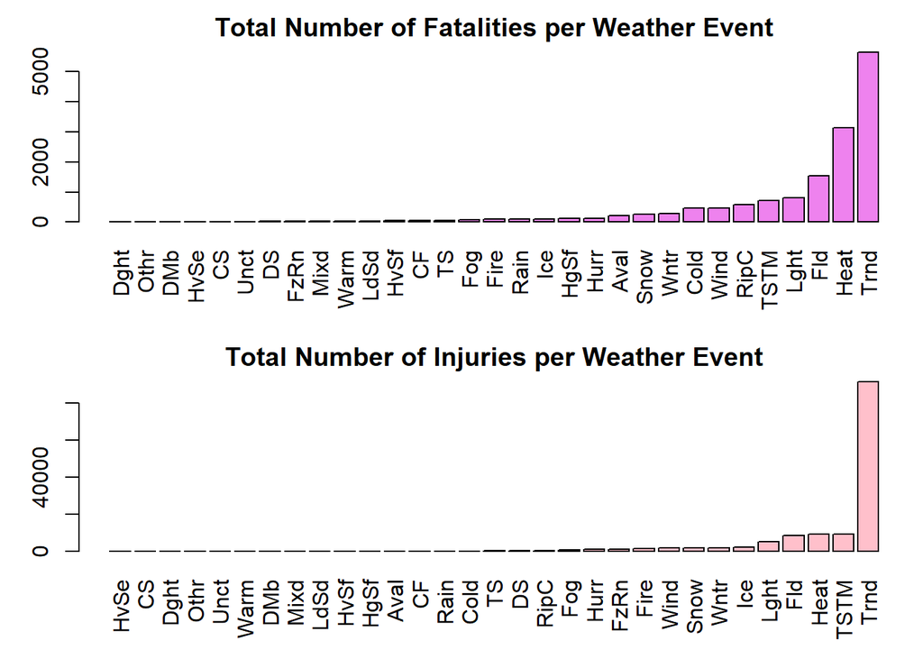

```r
#Setting abbreviations (in alphabetical order) for event types
fatalities$abbr <- c("Aval","CF","CS","Cold","Dght","DMb","DS","Fld","Fog","FzRn",
                     "Heat","HvSe","HvSf","HgSf","Hurr","Ice","LdSd","Lght","Mixd",
                     "Othr","Rain","RipC","Snow","TSTM","Trnd","TS","Unct","Warm",
                     "Fire","Wind","Wntr")
injuries$abbr <- c("Aval","CF","CS","Cold","Dght","DMb","DS","Fld","Fog","FzRn",
                     "Heat","HvSe","HvSf","HgSf","Hurr","Ice","LdSd","Lght","Mixd",
                     "Othr","Rain","RipC","Snow","TSTM","Trnd","TS","Unct","Warm",
                     "Fire","Wind","Wntr")

#Ordering fatalities and injuries by magnitude
fatalities2 <- fatalities[order(fatalities[,2],decreasing=FALSE),]
injuries2 <- injuries[order(injuries[,2],decreasing=FALSE),]

#Plotting
par(mar=c(4,3,2,.5),mfrow=c(2,1))
barplot(fatalities2$value, names.arg = fatalities2$abbr,
        las=3, col="violet",main="Total Number of Fatalities per Weather Event")
barplot(injuries2$value, names.arg = injuries2$abbr,
        las=3, col="pink",main="Total Number of Injuries per Weather Event")
```

##### *Economic damages*

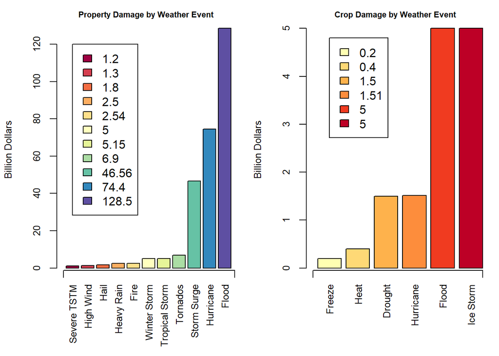

```r
property2 <- property1[order(property1[,"damage"],decreasing=FALSE),]
crop2 <- crop1[order(crop1[,"damage"],decreasing=FALSE),]

property2$abbr <- c("Severe TSTM","High Wind","Hail","Heavy Rain",
                    "Fire","Winter Storm","Tropical Storm","Tornados",
                    "Storm Surge","Hurricane","Flood")

library(RColorBrewer)

par(las=3,mfcol=c(1,2),cex.axis=.8,cex.lab=.8,mar=c(6,4,2,1),
    cex.main=.7,xaxt="s")
barplot(property2$damage,names.arg=property2$abbr,
        col=brewer.pal(11,"Spectral"),ylab= "Billion Dollars",
        xlab="",xlim=c(0,13), main="Property Damage by Weather Event")
axis(1, at=c(0,13.5), labels=FALSE, line=0)
legend(.7,120,legend=property2[,"damage"], fill=brewer.pal(11,"Spectral"))
barplot(crop2[,"damage"],names.arg=
            c("Freeze","Heat","Drought","Hurricane","Flood","Ice Storm"),
        col=brewer.pal(6,"YlOrRd"),ylab= "Billion Dollars",
        xlab="",xlim=c(0,7), main="Crop Damage by Weather Event")
axis(1, at=c(0,7.2), labels=FALSE, line=0)
legend(.7,4.8,legend=crop2[,"damage"], fill=brewer.pal(6,"YlOrRd"))
```